# Dynamic Factor Model Analysis with Prediction Intervals

Your Name

2025-11-07

# Introduction

This notebook demonstrates:

1. Simulation of data from a Dynamic Factor Model (DFM) with VAR(1) factors
2. Estimation using the `sparseDFM` package
3. Generation of prediction intervals via simulation
4. Model diagnostics and visualization

```r
# Install packages if needed
# install.packages(c("sparseDFM", "doSNOW", "fpp3", "forecast",
#                    "patchwork", "dCovTS", "ggplot2", "reshape2", "MASS"))

library(sparseDFM)
library(doSNOW)
library(fpp3)
library(forecast)
library(patchwork)
library(dCovTS)
library(ggplot2)
library(reshape2)
library(MASS)
```

# Part 1: Data Simulation

We simulate data from a Dynamic Factor Model:

$$\begin{align}
Y_t &= \Lambda F_t + \epsilon_t \\
F_t &= A F_{t-1} + u_t
\end{align}$$

Note that $\Lambda$ transforms the $r$ factors into the $n$ observations at each $t$. Thus this matrix can have interesting interpretations, for instance revealing which series share the same factor. In the sparseDFM package that we are using $\Lambda$ gets estimated more sparsely (i.e. with more zeros), which makes it easier to interpret.

We also note that $\Sigma_\epsilon$ is assumed to be diagonal, i.e. any correlation between the elements of $Y_t$ is strictly coming from the factors.

We first set the Parameters

```r
set.seed(123)

# Model dimensions
n_series <- 50      # number of observed time series
n_time <- 200       # number of time periods
r <- 3              # number of common factors
p <- 1              # VAR lag order for factors (VAR(1))
```

We then generate Factors with VAR(1) Dynamics…

```r
# VAR coefficient matrix for VAR(1)
Phi1 <- matrix(c(0.5, 0.1, 0.0,
                 0.1, 0.4, 0.1,
                 0.0, 0.1, 0.3), r, r)

print("VAR(1) coefficient matrix Phi1:")
```

```
## [1] "VAR(1) coefficient matrix Phi1:"
```

```r
print(Phi1)
```

```
##      [,1] [,2] [,3]
## [1,]  0.5  0.1  0.0
## [2,]  0.1  0.4  0.1
## [3,]  0.0  0.1  0.3
```

```r
# Initialize factors
factors <- matrix(0, n_time, r)
factors[1,] <- rnorm(r)

# Generate factors with VAR(1) dynamics: F_t = Phi1 * F_{t-1} + u_t
for(t in 2:n_time) {
  factors[t,] <- Phi1 %*% factors[t-1,] + rnorm(r, sd = 0.5)
}
```

… and visualize them:

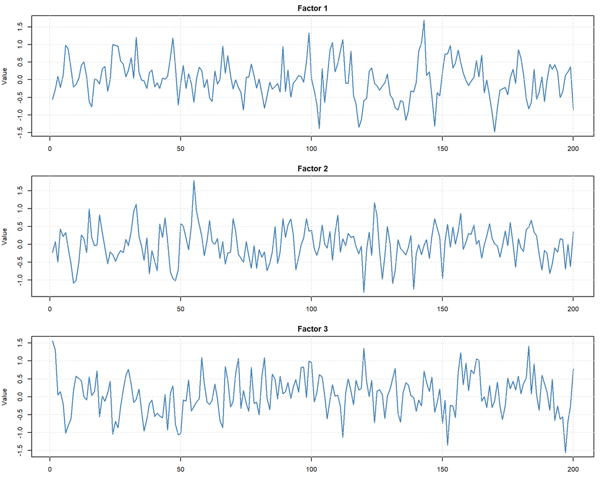

```r
par(mfrow = c(r, 1), mar = c(3, 4, 2, 1))
for(i in 1:r) {
  plot(factors[, i], type = "l", main = paste("Factor", i),
       ylab = "Value", xlab = "Time", col = "steelblue", lwd = 1.5)
  grid()
}
```

```r
par(mfrow = c(1, 1))
```

Given the factors, we now generate the loadings $\Lambda$ and the observed data…

```r
# Generate factor loadings (Lambda matrix)
Lambda <- matrix(runif(n_series * r, -1, 1), n_series, r)

# Generate observed data: y_t = Lambda * F_t + e_t
idiosyncratic_error <- matrix(rnorm(n_series * n_time, sd = 0.3),
                              n_time, n_series)
data_matrix <- factors %*% t(Lambda) + idiosyncratic_error

# Take first differences for stationarity
#data_matrix <- diff(data_matrix)

# Name the series
colnames(data_matrix) <- paste0("Series", 1:n_series)

cat("Data dimensions (after differencing):", dim(data_matrix), "\n")
```

```
## Data dimensions (after differencing): 200 50
```

```r
cat("Number of observations:", nrow(data_matrix), "\n")
```

```
## Number of observations: 200
```

```r
cat("Number of series:", ncol(data_matrix), "\n")
```

```
## Number of series: 50
```

… and visualize:

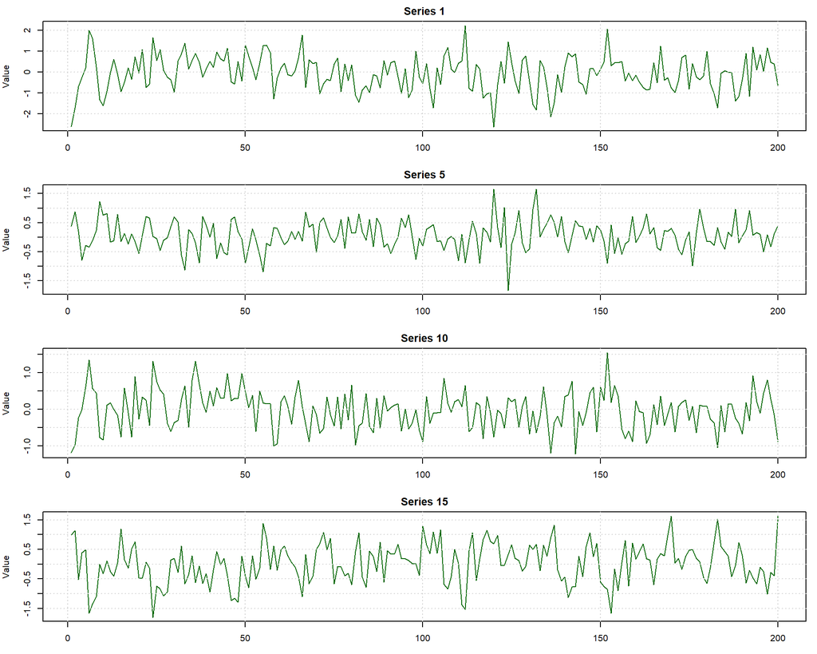

```r
series_to_show <- c(1, 5, 10, 15)
par(mfrow = c(length(series_to_show), 1), mar = c(3, 4, 2, 1))
for(i in series_to_show) {
  plot(data_matrix[, i], type = "l", main = paste("Series", i),
       ylab = "Value", xlab = "Time", col = "darkgreen", lwd = 1)
  grid()
}
```

```r
par(mfrow = c(1, 1))
```

We can also look at the correlation between $Y_t$ (or its first few elements):

```r
cor(data_matrix[1:5,1:5])
```

```
##            Series1    Series2    Series3    Series4    Series5
## Series1  1.0000000  0.2480764 -0.4937939 -0.8287581 -0.7184490
## Series2  0.2480764  1.0000000 -0.5094212  0.2111798 -0.1592242
## Series3 -0.4937939 -0.5094212  1.0000000  0.1849248  0.4738410
## Series4 -0.8287581  0.2111798  0.1849248  1.0000000  0.8300802
## Series5 -0.7184490 -0.1592242  0.4738410  0.8300802  1.0000000
```

# Part 2: Model Estimation

We now split into test and training set:

```r
Y <- data_matrix

n_train <- 180
n_test <- nrow(Y) - n_train

Y_train <- Y[1:n_train, ]
Y_test <- Y[(n_train+1):nrow(Y), ]

cat("Training set size:", n_train, "\n")
```

```
## Training set size: 180
```

```r
cat("Test set size:", n_test, "\n")
```

```
## Test set size: 20
```

Note that for real data we could now use

```r
#new_data <- transformData(Y_train, stationary_transform=2)## First difference
```

to try to find a differencing such that the data becomes stationary. Here we simulated data, so this is not necessary.

```r
# Use tuneFactors to identify optimal number of factors
factor_selection <- tuneFactors(Y_train)
```

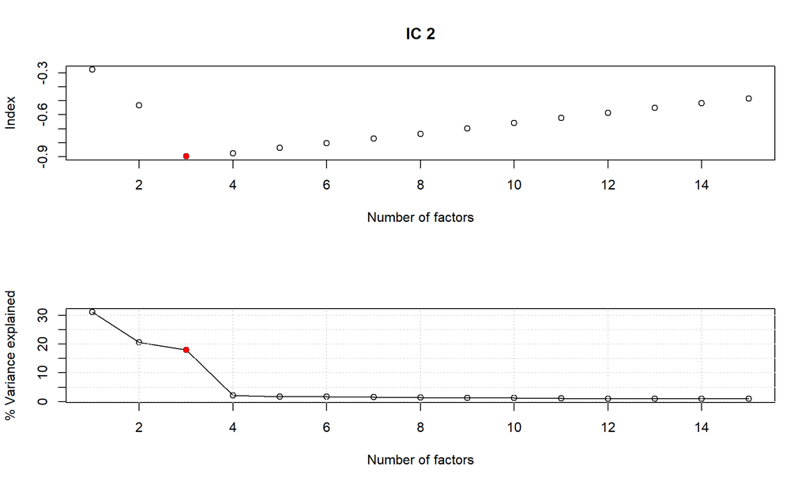

```r
print(factor_selection)
```

```
## [1] "The chosen number of factors using criteria type  2  is  3"
```

The function correctly identifies 3 factors!

We now estimate the sparse version of the Dynamical Factor Model:

```r
# Estimate sparse DFM
fit <- sparseDFM(
  X = Y_train,
  r = 3,              # number of factors
  alg = "EM-sparse"
)

# View model summary
summary(fit)
```

```
##
## Call:
##
##  sparseDFM(X = Y_train, r = 3, alg = "EM-sparse")
##
##  Sparse Dynamic Factor Model using EM-sparse with:
##
##  n = 180 observations,
##  p = 50 variables,
##  r = 3 factors,
##  err = IID
##
##  The r x r factor transition matrix A
##            F1          F2          F3
## F1 0.53242958  0.01483797 -0.05967608
## F2 0.05121293  0.30551880 -0.04465747
## F3 0.04540665 -0.06952326  0.38777034
##
##
##  The r x r factor transition error covariance matrix Sigma_u
##            u1         u2         u3
## u1 11.4595403 -0.7449846 -0.1116019
## u2 -0.7449846  8.9796795  0.2456169
## u3 -0.1116019  0.2456169  7.6068047
```

Note that if we instead used

```r
# Estimate sparse DFM
fitnonsparse <- sparseDFM(
  X = Y_train,
  r = 3,              # number of factors
  alg = "EM"
)

# View model summary
summary(fitnonsparse)
```

```
##
## Call:
##
##  sparseDFM(X = Y_train, r = 3, alg = "EM")
##
##  Dynamic Factor Model using EM with:
##
##  n = 180 observations,
##  p = 50 variables,
##  r = 3 factors,
##  err = IID
##
##  The r x r factor transition matrix A
##            F1          F2          F3
## F1 0.51571524  0.06037802 -0.04472157
## F2 0.06283954  0.34927632 -0.07016409
## F3 0.06017420 -0.06591870  0.35529425
##
##
##  The r x r factor transition error covariance matrix Sigma_u
##            u1         u2         u3
## u1 11.4595403 -0.7449846 -0.1116019
## u2 -0.7449846  8.9796795  0.2456169
## u3 -0.1116019  0.2456169  7.6068047
```

we would get a version with less zeros in $\Lambda$.

There are now various diagnostic and plotting tools available! First, we produce Factor plots

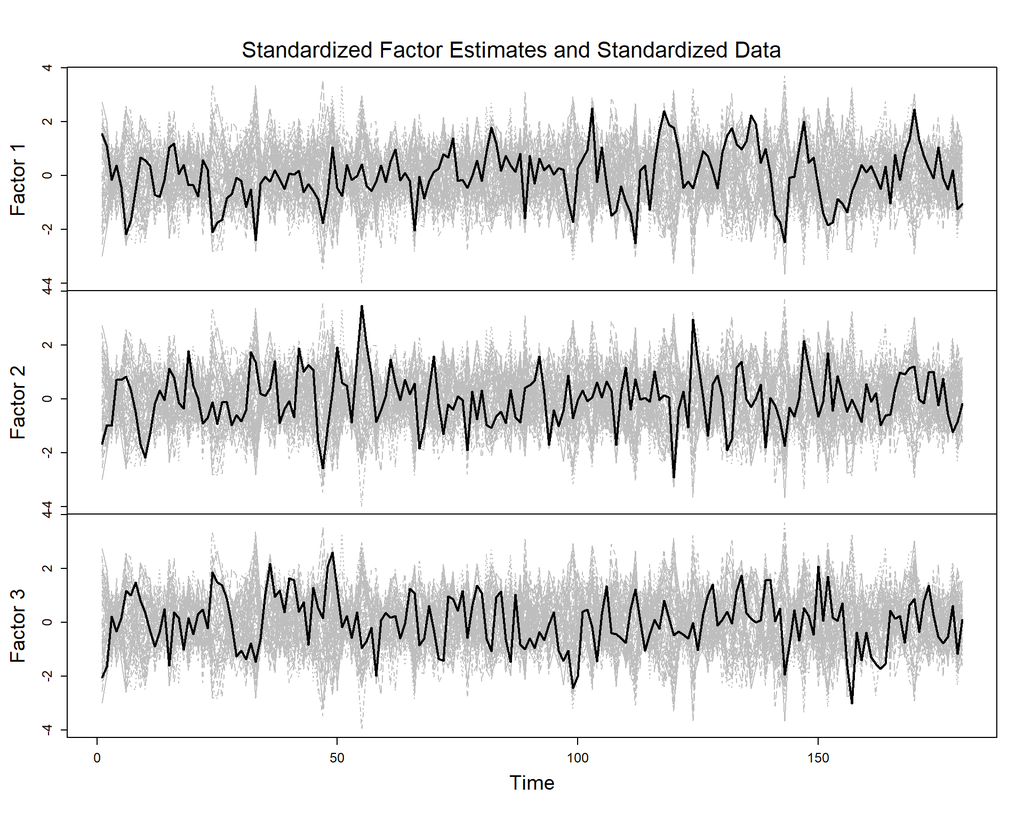

```r
plot(fit, type = "factor")
```

As before we can also do residual diagnostics

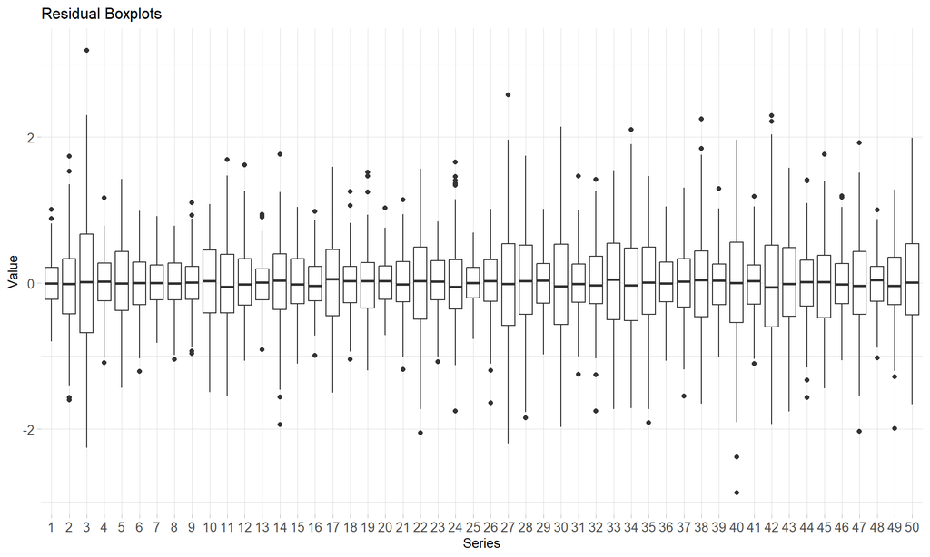

```r
plot(fit, type = "residual")
```

Here of course these boxplots look as expected, as the data are simulated. As before, we can also calculate the distance autocorrelation of residuals, checking for remaining dependence structure in residuals (outcommented because of long calculation time)

```r
#resid <- residuals(fit)
#mADCFplot(resid)  # This may take a while
```

Interesting we can also plot the heatmap of factors. This should illustrate the $\Lambda$ matrix and how Factors are transformed into observations:

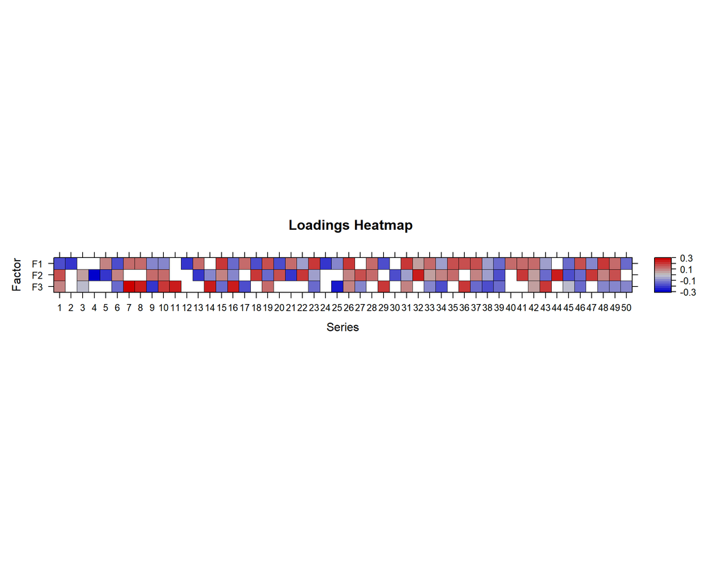

```r
plot(fit, type = "loading.heatmap")
```

# Part 3: Forecasting with Prediction Intervals

The package unfortunately only creates predictions of the (conditional) expectations of factors and the series. However, we generate prediction intervals by simulating from the estimated DFM:

1. Draw $F_{T+h}$ from the VAR(1) process
2. Draw $Y_{T+h}$ conditional on $F_{T+h}$

```r
generate_prediction_intervals <- function(fit, h, n_sim = 1000, level = 0.95) {

  # Extract model components
  # Y_t = Lambda * F_t + epsilon_t
  # F_t = A * F_{t-1} + u_t

  A <- fit$params$A                    # VAR coefficients
  Lambda <- fit$params$Lambda          # n_series x r
  Sigma_u <- fit$params$Sigma_u        # r x r
  Sigma_epsilon <- fit$params$Sigma_epsilon  # n_series x n_series (diagonal)

  n_series <- nrow(Lambda)
  r <- ncol(Lambda)
  p <- fit$p  # VAR lag order

  # Storage for simulations
  Y_sim <- array(NA, dim = c(h, n_series, n_sim))

  # Get E[F_{T+1} | F_T]
  FT1 <- predict(fit)$F_hat

  # Simulate from the DFM
  for(sim in 1:n_sim) {

    # Initialize factor simulations
    F_sim <- matrix(NA, h, r)

    # Draw F_{T+1} ~ N(E[F_{T+1}|F_T], Sigma_u)
    F_sim[1, ] <- FT1 + mvrnorm(1, mu = rep(0, r), Sigma = Sigma_u)

    # Draw Y_{T+1} | F_{T+1}
    Y_sim[1, , sim] <- Lambda %*% F_sim[1, ] +
      mvrnorm(1, mu = rep(0, n_series), Sigma = diag(Sigma_epsilon))

    # Simulate forward h-1 more steps
    for(t in 2:h) {
      # Simulate F_t from VAR(1): F_t = A * F_{t-1} + u_t
      F_sim[t, ] <- A %*% F_sim[t-1, ] +
        mvrnorm(1, mu = rep(0, r), Sigma = Sigma_u)

      # Simulate Y_t | F_t
      Y_sim[t, , sim] <- Lambda %*% F_sim[t, ] +
        mvrnorm(1, mu = rep(0, n_series), Sigma = diag(Sigma_epsilon))
    }
  }

  # Calculate prediction intervals
  alpha <- 1 - level
  lower <- apply(Y_sim, c(1, 2), quantile, probs = alpha/2, na.rm = TRUE)
  upper <- apply(Y_sim, c(1, 2), quantile, probs = 1 - alpha/2, na.rm = TRUE)
  median_forecast <- apply(Y_sim, c(1, 2), median, na.rm = TRUE)

  return(list(
    median = median_forecast,
    lower = lower,
    upper = upper,
    simulations = Y_sim
  ))
}
```

Then we use this function to generate predictions,

```r
set.seed(456)

# Generate 90% prediction intervals
pred_intervals <- generate_prediction_intervals(
  fit = fit,
  h = n_test,
  n_sim = 1000,
  level = 0.90
)

# Get point forecasts from predict method
predictions <- predict(
  object = fit,
  h = n_test,
  X_new = NULL
)
Y_pred <- predictions$X_hat

cat("Prediction intervals generated successfully!\n")
```

```
## Prediction intervals generated successfully!
```

```r
cat("Forecast horizon:", n_test, "periods\n")
```

```
## Forecast horizon: 20 periods
```

```r
cat("Number of simulations:", 1000, "\n")
```

```
## Number of simulations: 1000
```

and visualize some of the forecasts with prediction intervals:

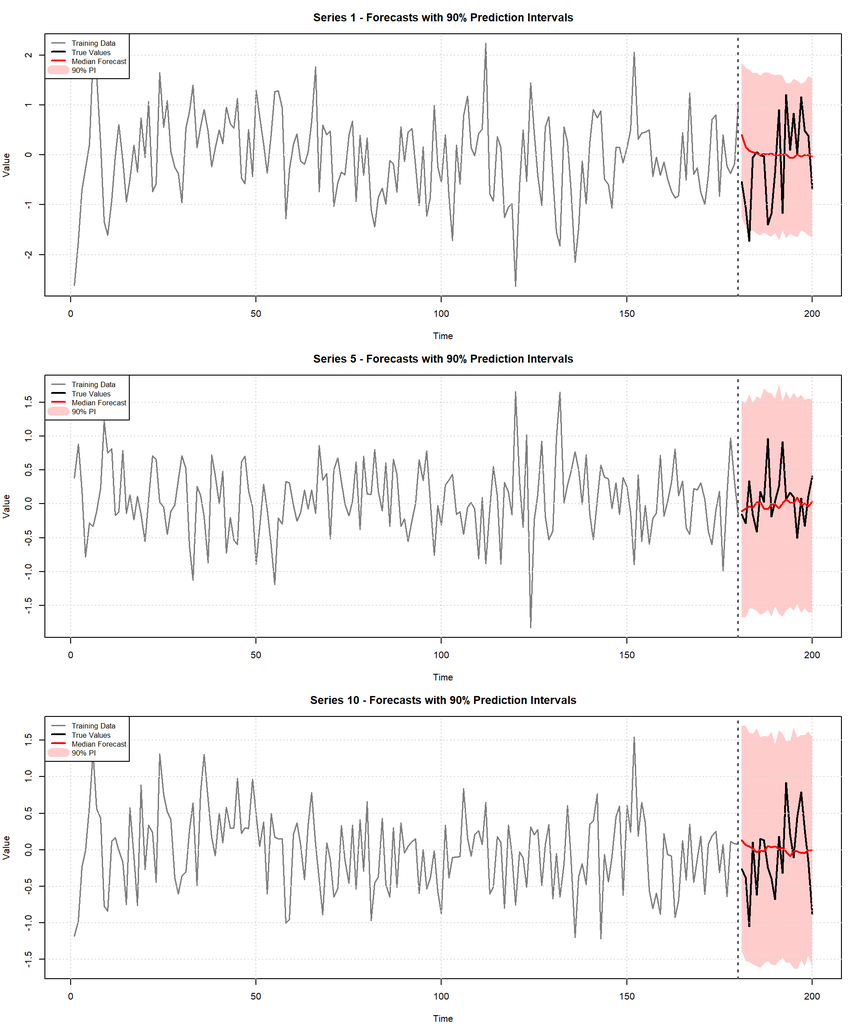

```r
# Plot forecasts for selected series with prediction intervals
series_to_plot <- c(1, 5, 10)

par(mfrow = c(length(series_to_plot), 1), mar = c(4, 4, 3, 1))
for(i in series_to_plot) {

  # Determine y-axis limits
  y_range <- range(c(Y_train[, i], Y_test[, i],
                     pred_intervals$lower[, i], pred_intervals$upper[, i]),
                   na.rm = TRUE)

  # Plot training data
  plot(1:n_train, Y_train[, i], type = "l",
       xlim = c(1, n_train + n_test),
       ylim = y_range,
       main = paste("Series", i, "- Forecasts with 90% Prediction Intervals"),
       xlab = "Time", ylab = "Value", col = "gray50", lwd = 1.5)

  # Add forecast period separator
  abline(v = n_train, col = "gray30", lty = 3, lwd = 2)

  # Add prediction interval as shaded region
  time_forecast <- (n_train+1):(n_train+n_test)
  polygon(c(time_forecast, rev(time_forecast)),
          c(pred_intervals$lower[, i], rev(pred_intervals$upper[, i])),
          col = rgb(1, 0, 0, 0.2), border = NA)

  # Add actual test values
  lines(time_forecast, Y_test[, i], col = "black", lwd = 2)

  # Add median forecast
  lines(time_forecast, pred_intervals$median[, i], col = "red", lwd = 2, lty = 1)

  grid()

  # Add legend
  legend("topleft",
         legend = c("Training Data", "True Values", "Median Forecast", "90% PI"),
         col = c("gray50", "black", "red", rgb(1, 0, 0, 0.2)),
         lty = c(1, 1, 1, 1), lwd = c(1.5, 2, 2, 10),
         cex = 0.8, bg = "white")
}
```

```r
par(mfrow = c(1, 1))
```

We can of course also look at multiple quantiles at once:

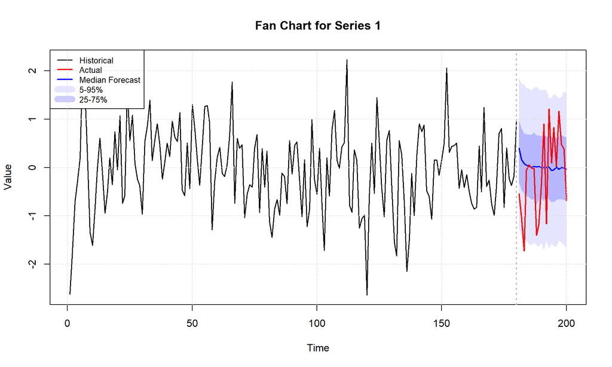

```r
# Create a fan chart showing multiple quantiles
series_idx <- 1
quantiles <- c(0.05, 0.25, 0.50, 0.75, 0.95)

q_forecasts <- t(apply(pred_intervals$simulations[, series_idx, ], 1,
                     quantile, probs = quantiles))

time_all <- 1:(n_train + n_test)
time_forecast <- (n_train+1):(n_train+n_test)

# Plot
y_range <- range(c(Y_train[, series_idx], Y_test[, series_idx], q_forecasts),
                 na.rm = TRUE)

plot(1:n_train, Y_train[, series_idx], type = "l", lwd = 1.5,
     xlim = range(time_all), ylim = y_range,
     main = paste("Fan Chart for Series", series_idx),
     xlab = "Time", ylab = "Value", col = "black")

abline(v = n_train, col = "gray", lty = 3, lwd = 2)

# Add shaded regions for different quantiles
polygon(c(time_forecast, rev(time_forecast)),
        c(q_forecasts[, 1], rev(q_forecasts[, 5])),
        col = rgb(0, 0, 1, 0.1), border = NA)
polygon(c(time_forecast, rev(time_forecast)),
        c(q_forecasts[, 2], rev(q_forecasts[, 4])),
        col = rgb(0, 0, 1, 0.2), border = NA)

# Add median
lines(time_forecast, q_forecasts[, 3], col = "blue", lwd = 2)

# Add actual values
lines(time_forecast, Y_test[, series_idx], col = "red", lwd = 2)

legend("topleft",
       legend = c("Historical", "Actual", "Median Forecast", "5-95%", "25-75%"),
       col = c("black", "red", "blue", rgb(0, 0, 1, 0.1), rgb(0, 0, 1, 0.2)),
       lty = 1, lwd = c(1.5, 2, 2, 10, 10), cex = 0.8)
grid()
```

# Part 5: Probability Forecasts

With the simulation approach, we can easily predict probabilities:

```r
# Example: Probability that Series 1 exceeds a threshold at h=1
threshold <- 0.5
prob_exceed <- mean(pred_intervals$simulations[1, 1, ] > threshold)

cat(sprintf("P(Series 1 > %.2f at h=1) = %.3f\n", threshold, prob_exceed))
```

```
## P(Series 1 > 0.50 at h=1) = 0.457
```

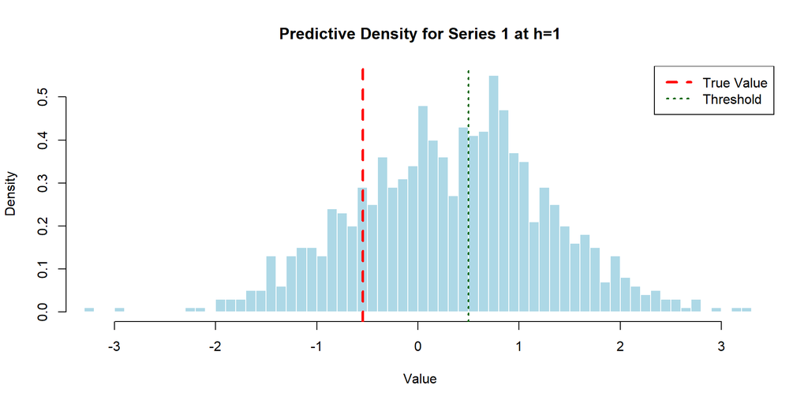

```r
# Visualize predictive density
hist(pred_intervals$simulations[1, 1, ], breaks = 50, freq = FALSE,
     main = "Predictive Density for Series 1 at h=1",
     xlab = "Value", col = "lightblue", border = "white",
     xlim = range(c(pred_intervals$simulations[1, 1, ], Y_test[1, 1])))
abline(v = Y_test[1, 1], col = "red", lwd = 3, lty = 2)
abline(v = threshold, col = "darkgreen", lwd = 2, lty = 3)
legend("topright",
       legend = c("True Value", "Threshold"),
       col = c("red", "darkgreen"), lty = c(2, 3), lwd = c(3, 2))
```